# Genetic Interaction Exploration based on Gene Expression

Martin Brand

Kathi Zarnack

2023-01-02 - 2023-06-29

Abstract

The workflow explores genetic interactions in cell lines with high or low expression of a selected gene. It uses an expression dataset to classify the cell lines in highly expressing and lowly expressing cell lines. Using the gene-screening datasets, it then compares the two samples to identify significant differences in gene dependencies.

```r
Sys.setenv(LANG = "en")
library(dplyr)
library(ggplot2)
library(kableExtra)
library(matrixTests)
library(limma)
library(ggrepel)
library(gridExtra)
library(ComplexHeatmap)
library(Rgraphviz)
library(CePa)
```

# Classification settings and target genes

First, we define the input data for the workflow: the gene we use for classification into high and low expressing cell lines, the sample share that determines how many cell lines are considered and the target genes to be displayed in the volcano plots.

```r
# choose the genes that should be labeled in the result plots
target.genes <- c("SNRPF")

# select the gene on which to base the classification
# you must specify the gene name and its Entrez ID
classification.gene.HUGO <- "SNRPF"
classification.gene <- "6636"

# select the sample portion of the cell lines
# e.g. 0.2 means that 20% with highest expression are tested
# against 20% with lowest expression
sample.share <- 0.2
```

# Data Preprocessing

We load the gene expression dataset ([CCLE expression dataset](https://depmap.org/portal/download/all/?releasename=mRNA+expression&filename=CCLE_Expression_Entrez_2012-09-29.gct)) and the datasets that contains the dependency scores from the projects Achilles and DRIVE ([DepMap datasets](https://figshare.com/articles/dataset/DepMap_Datasets_for_WRN_manuscript/7712756/1)).

```r
path <- "C:/Users/Martin/Documents/Master/Thesis/CCLE_data/"
expression.data <-
  read.gct(
    paste0(path, "Expression_Files/CCLE_Expression_Entrez_2012-09-29.gct"))
expression.data <- as.data.frame(expression.data)
saveRDS(expression.data,
        file=paste0(path, "Expression_Files/expression.data.rds"))
```

```r
# specify the path to the expression dataset
path <- "C:/Users/Martin/Documents/Master/Thesis/CCLE_data/"

# load CCLE expression dataset
expression.data <- readRDS(paste0(path, "Expression_Files/expression.data.rds"))

# change rownames format
expression.data.entrez <- expression.data
rownames(expression.data.entrez) <-
  substr(rownames(expression.data), 1, nchar(rownames(expression.data)) - 3)
# make rownames to first column
expression.data.entrez$entrezgene_id <- rownames(expression.data.entrez)
rownames(expression.data.entrez) <- NULL
expression.data.entrez <- expression.data.entrez %>%
  select(entrezgene_id, everything())

# load Achilles and DRIVE gene-screening datasets
path <-
  "C:/Users/Martin/Documents/Master/Thesis/genetic_dependency_detection/data/"
dep.scores.DRIVE <- readRDS(paste0(path, "dep.scores.DRIVE.rds"))
dep.scores.Achilles <- readRDS(paste0(path, "dep.scores.Achilles.rds"))

rm(path,expression.data)
```

```r
source("helper_functions/calc.mean.diffs.and.p.values.R")
source("helper_functions/create_volcano_plot.R")
source("helper_functions/create.classification.table.expr.R")
source("helper_functions/find.significant.genes.R")
source("helper_functions/create.upset.plot.R")
source("helper_functions/list.significant.genes.R")
```

# Gene expression distribution of SNRPF

To investigate the expression levels of the chosen classification gene, we plot the distribution of expression levels in the different cell lines.

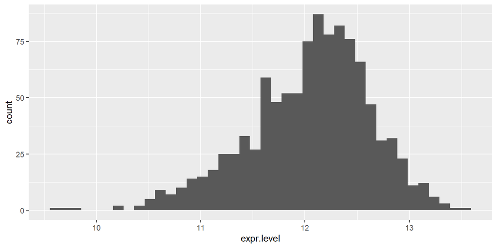

```r
# extract expression levels of selected gene
expression.class.gene <- as.data.frame(
  t(filter(expression.data.entrez,entrezgene_id == classification.gene))[-1, ])
expression.class.gene$CCLE_ID <- rownames(expression.class.gene)
rownames(expression.class.gene) <- NULL
colnames(expression.class.gene) <- c("expr.level", "CCLE_ID")
expression.class.gene$expr.level <- as.numeric(expression.class.gene$expr.level)

# plot distribution of expression levels over cell lines
ggplot(expression.class.gene, aes(expr.level)) +
  geom_histogram(bins = 40)
```

```r
rm(expression.data.entrez, classification.gene)
```

# Classification

We create two samples. One sample contains the cell lines with high expression and the other contains the cell lines with low expression of the selected gene. We summarise the samples in a classification table that shows whether a cell line is highly expressing or lowly expressing. For illustration, we show the beginning of the classification table for the cell lines in the DRIVE dataset.

```r
class.tables <- create.classification.table.expr(
  sample.share = sample.share,
  expression.class.gene = expression.class.gene,
  dep.scores.DRIVE = dep.scores.DRIVE,
  dep.scores.Achilles = dep.scores.Achilles)

class.table.DRIVE <- class.tables$DRIVE
class.table.Achilles <- class.tables$Achilles

rm(sample.share, expression.class.gene)

# show one table as example
class.table.DRIVE %>%
  head() %>%
  kbl(caption = "Classification Table in DRIVE",
      col.names = c("CCLE_ID", "isHighlyExpressing")) %>%
  kable_styling()
```

Table 1: Classification Table in DRIVE

| CCLE_ID | isHighlyExpressing |
| --- | --- |
| SNU761_LIVER | FALSE |
| COLO678_LARGE_INTESTINE | FALSE |
| HS729_SOFT_TISSUE | FALSE |
| SU8686_PANCREAS | FALSE |
| VMRCRCW_KIDNEY | FALSE |
| HS578T_BREAST | FALSE |

# Comparion between highly expressing and lowly expressing cell lines

To test whether the two samples respond differently to the knockout or the knockdown of a specific gene, we calculate the mean differences between the dependency scores of both samples for each gene. We then compare the two samples using various statistical tests.

## Welch’s t-test

```r
res <- calc.mean.diffs.and.p.values(
  dep_scores_DRIVE = dep.scores.DRIVE,
  dep_scores_Achilles = dep.scores.Achilles,
  CCLE_mut_DRIVE = class.table.DRIVE,
  CCLE_mut_Achilles = class.table.Achilles)

rm(class.table.DRIVE, class.table.Achilles, class.tables,dep.scores.DRIVE,
   dep.scores.Achilles)
```

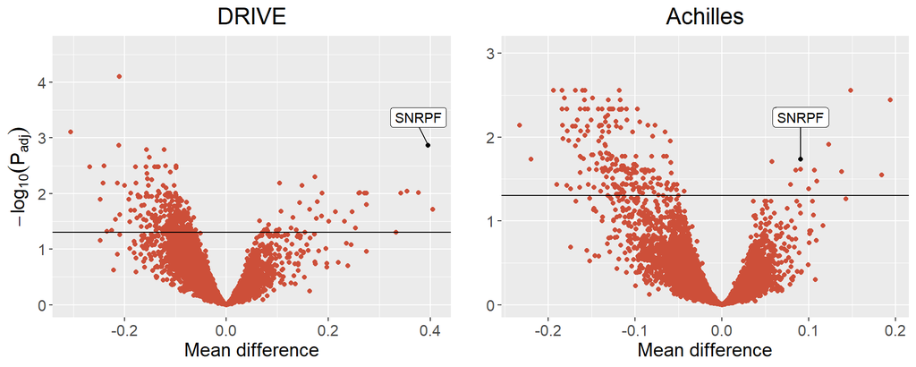

```r
plot.welch.DRIVE <- create_volcano_plot(
  test_results = res,
  dataset = "DRIVE",
  test_method = "welch",
  labeled_genes = target.genes)

plot.welch.Achilles <- create_volcano_plot(
  test_results = res,
  dataset = "Achilles",
  test_method = "welch",
  labeled_genes =  target.genes,
  show_y_label = F)

grid.arrange(plot.welch.DRIVE, plot.welch.Achilles, ncol = 2)
```

```r
rm(plot.welch.DRIVE, plot.welch.Achilles)
```

## Wilcoxon ranked-sum test

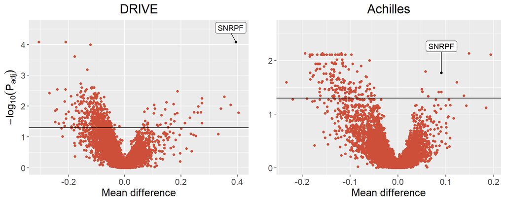

```r
plot.wilc.DRIVE <- create_volcano_plot(
  test_results = res,
  dataset = "DRIVE",
  test_method = "wilc",
  labeled_genes = target.genes)

plot.wilc.Achilles <- create_volcano_plot(
  test_results = res,
  dataset = "Achilles",
  test_method = "wilc",
  labeled_genes = target.genes,
  show_y_label = F)

grid.arrange(plot.wilc.DRIVE, plot.wilc.Achilles, ncol = 2)
```

```r
rm(plot.wilc.DRIVE, plot.wilc.Achilles)
```

## Bayes moderated t-test

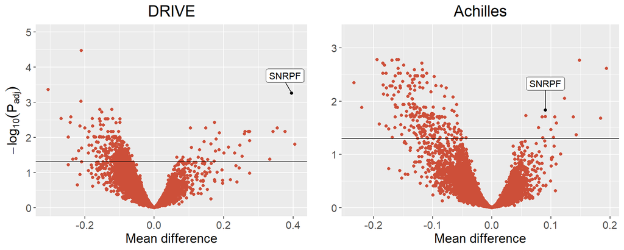

```r
plot.bayes.DRIVE <- create_volcano_plot(
  test_results = res,
  dataset = "DRIVE",
  test_method = "bayes",
  labeled_genes = target.genes)

plot.bayes.Achilles <- create_volcano_plot(
  test_results = res,
  dataset = "Achilles",
  test_method = "bayes",
  labeled_genes = target.genes,
  show_y_label = F)

grid.arrange(plot.bayes.DRIVE, plot.bayes.Achilles, ncol = 2)
```

```r
rm(plot.bayes.DRIVE, plot.bayes.Achilles, target.genes)
```

# Significant genes

## Upset plots

To investigate whether genes have significant p-values in multiple tests and datasets, we create an upset plot. Each set contains all genes that are significant in the corresponding dataset and test method.

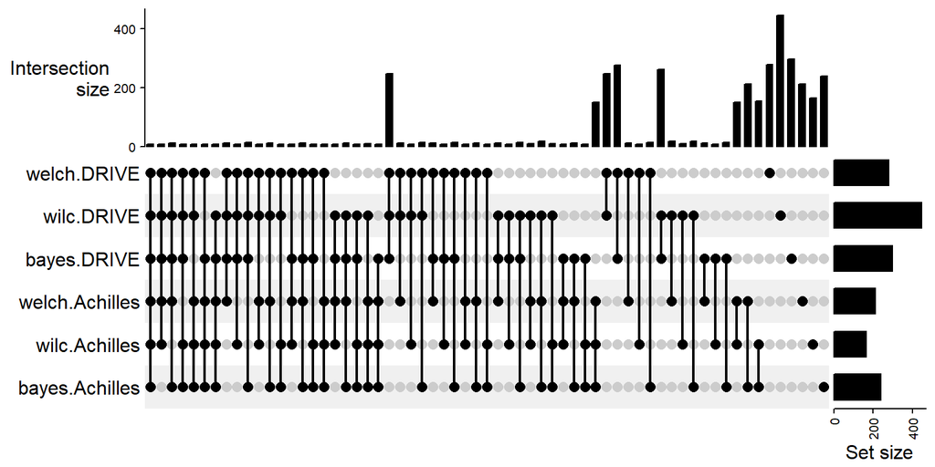

```r
significant.genes <- find.significant.genes(res = res)

create.upset.plot(significant.genes)
```

```r
rm(res)
```

## Significant genes

We list the genes that appear in the maximum number of significant gene sets.

```r
final.significant.genes <- list.significant.genes(significant.genes)

# show result
final.significant.genes$final.significant.genes['geneID'] %>%
  kbl(caption = paste("Genes that are significant in",
                      final.significant.genes$max.set, "sets.")) %>%
  kable_styling()
```

Table 2: Genes that are significant in 6 sets.

| geneID |
| --- |
| PLK4 |
| CYC1 |
| EEF2 |
| TAF5L |
| NDUFB5 |
| SCD |
| SNRPF |
| TTF2 |
| SART3 |

```r
rm(significant.genes, final.significant.genes)
```